# Sediments and Sedimentary Rocks

Dr. Ahmad Redaa

2025-02-01

# **Sedimentary Rock Formation Processes**

### **1. Weathering**

- **Definition:**  
  Breakdown of pre-existing rocks into smaller particles through physical, chemical, or biological processes.
- **Contribution to Sediments:**
  - Physical weathering (mechanical breakdown) increases sediment supply.
  - Chemical weathering dissolves minerals, forming dissolved ions that can later precipitate.

### **2. Erosion**

- **Definition:**  
  The removal and movement of weathered material from its source.
- **Agents of Erosion:**
  - Wind
  - Water
  - Ice
  - Gravity
- **Significance:**  
  Erosion exposes fresh rock surfaces to further weathering.

### **3. Transportation**

- **Definition:**  
  The movement of sediments from one location to another.
- **Transport Mechanisms:**
  - Wind (e.g., desert dunes)
  - Running water (e.g., rivers transporting sand and silt)
  - Glaciers (e.g., moving large boulders and sediments)
- **Impact:**
  - Determines the shape, size, and sorting of sediments.
  - Rounds sediments due to abrasion.

### **4. Deposition**

- **Definition:**  
  The process where transported sediments settle or accumulate.
- **Triggers for Deposition:**
  - Reduction in transport energy (e.g., river slows down)
  - Changes in water or air velocity
- **Examples:**
  - River deltas
  - Sand dunes
  - Glacier deposits

### **How Deposition Occurs**

- **When energy of transport medium decreases**, sediments settle.
- **Examples:**
  - **Rivers slowing down** → Deposits sediments in deltas.
  - **Wind dying down** → Forms sand dunes.

### **Chemical Deposition (Precipitation)**

- **Definition:**  
  Dissolved materials precipitate and form solid minerals due to **changes in temperature, pressure, or chemical composition**.
- **Examples:**
  - **Evaporation of seawater** → Formation of **salt crystals**.
  - **Limestone formation** from dissolved calcium carbonate.

### **5. Compaction**

- **Definition:**  
  The process where sediment layers accumulate and compress due to overlying pressure.
- **Effect:**
  - Reduces pore space between grains.
  - Expels water from sediments.
- **Example:**
  - Mud transforming into shale.

### **6. Cementation**

- **Definition:**  
  The binding of sediment particles by minerals precipitated from groundwater.
- **Common Cementing Agents:**
  - Silica
  - Calcium carbonate
  - Iron oxides
- **Result:**
  - Formation of solid sedimentary rock (e.g., sandstone, limestone).

# **Formation Processes**

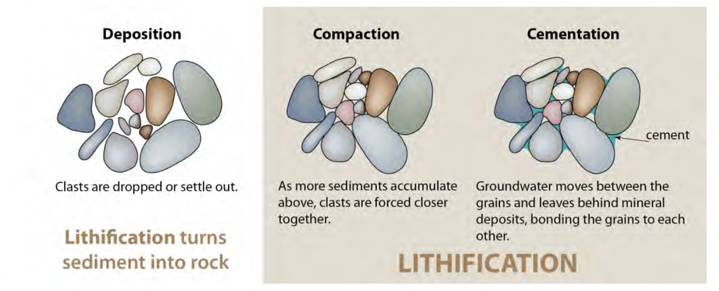

Source: [Steven, E. (2015)](https://openlibrary-repo.ecampusontario.ca/jspui/handle/123456789/402)

# **Classification of Sedimentary Rocks**

Sedimentary rocks are classified into three main types based on their origin:

1. **Clastic Sedimentary Rocks** (formed from rock fragments)
2. **Chemical Sedimentary Rocks** (formed from mineral precipitation)
3. **Organic Sedimentary Rocks** (formed from biological material)

Each type forms through different geological processes.

# **1. Clastic Sedimentary Rocks**

### **Definition**

- Formed from **mechanically weathered and transported** rock fragments.
- Classified based on **sediment grain size**.

### **Grain Size and Resulting Rocks**

| Sediment Size | Rock Type | Example |
| --- | --- | --- |
| **> 2 mm** | **Conglomerate** (rounded) / **Breccia** (angular) | River gravel deposits |
| **0.06 – 2 mm** | **Sandstone** | Beach, desert dunes |
| **0.002 – 0.06 mm** | **Siltstone** | River floodplains |
| **< 0.002 mm** | **Shale / Mudstone** | Deep marine, lake deposits |

- **Sorting & Rounding:**
  - **Well-sorted:** Long transport distance (e.g., beach sand).
  - **Poorly sorted:** Short transport distance (e.g., glacial deposits).

### **Grain Size**

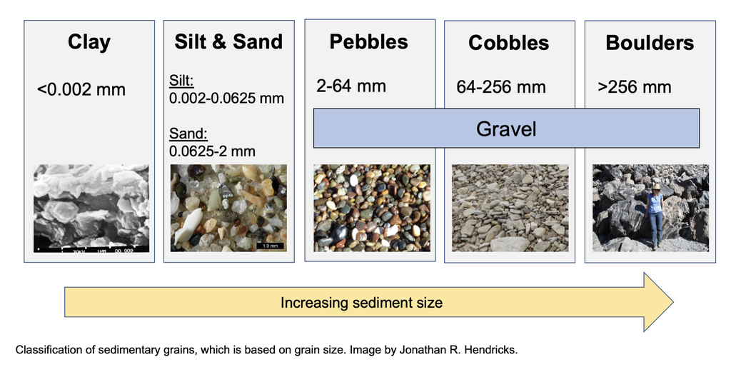

Source: [Digital Atlas of Ancient Life](https://www.digitalatlasofancientlife.org/learn/paleoecology/paleoenvironmental-reconstruction/)

# **2. Chemical Sedimentary Rocks**

### **Definition**

- Formed when **minerals precipitate** from solution due to changes in temperature, pressure, or water chemistry.
- Typically found in **evaporite deposits, caves, and ocean basins**.

### **Common Chemical Sedimentary Rocks**

| Rock Type | Composition | Formation Environment | Example |
| --- | --- | --- | --- |
| **Limestone** | Calcite (CaCO₃) | Marine, caves | Coral reefs, stalactites |
| **Dolostone** | Dolomite (CaMg(CO₃)₂) | Altered limestone | Shallow marine |
| **Chert** | Microcrystalline silica (SiO₂) | Deep-sea | Flint, jasper |
| **Rock Salt** | Halite (NaCl) | Evaporation of seawater | Salt flats |
| **Gypsum** | Calcium sulfate (CaSO₄·2H₂O) | Evaporite deposits | Dry lake beds |

- **Evaporation & Precipitation:**
  - Example: **Evaporation of seawater** → Precipitation of **halite (rock salt)**.
  - Example: **Cave water dripping** → Formation of **stalactites and stalagmites**.

# **3. Organic Sedimentary Rocks**

### **Definition**

- Formed from **accumulation of organic material** (plants, shells, or microscopic organisms).
- Typically associated with **swamps, marine environments, and coral reefs**.

### **Examples of Organic Rocks**

| Rock Type | Composition | Formation Environment | Example |
| --- | --- | --- | --- |
| **Coal** | Carbon from compressed plant material | Swamps | Peat, bituminous coal |
| **Chalk** | Microscopic calcite shells (plankton) | Deep marine | White Cliffs of Dover |
| **Coquina** | Fragmented shells (CaCO₃) | Shallow marine | Florida coquina limestone |

- **Coal Formation Stages:**
  1. **Peat** → 2. **Lignite** → 3. **Bituminous Coal** → 4. **Anthracite**
  - Each stage increases in **carbon content and energy**.
- **Marine Carbonates:**
  - Example: **Coral reefs and shell deposits** forming **limestone**.

# **Clastic Sedimentary Rocks**

| Rock Type | Description & Characteristics | Example Locations |
| --- | --- | --- |
| **Conglomerate** | Composed of rounded gravel-sized clasts in a finer matrix | Riverbeds, alluvial fans |
| **Breccia** | Composed of angular rock fragments in a finer matrix | Fault zones, landslides |
| **Sandstone** | Made of sand-sized quartz, feldspar, or rock fragments | Deserts, beaches, rivers |
| **Arkose** | A feldspar-rich sandstone with a pinkish-red hue | Alluvial fans, riverbeds |
| **Ferruginous Sandstone** | Sandstone with iron oxide cement, giving a reddish-brown color | Coastal and desert areas |
| **Grit** | Coarse-grained, angular rock fragments | Mountainous regions, river channels |
| **Graywacke** | Poorly sorted sandstone with a muddy matrix | Deep marine settings, turbidites |

# **Fine-Grained Clastic Sedimentary Rocks**

| Rock Type | Description & Characteristics | Example Locations |
| --- | --- | --- |
| **Clay** | Fine-grained sediment, forms shale and mudstone | River deltas, deep ocean |
| **Silt** | Slightly coarser than clay, forms siltstone | Floodplains, riverbanks |
| **Marl** | A mixture of clay and calcium carbonate | Lagoons, lake beds |

# **Chemical Sedimentary Rocks**

| Rock Type | Description & Characteristics | Example Locations |
| --- | --- | --- |
| **Oolitic Limestone** | Formed from spherical grains (ooids) cemented by calcite | Warm, shallow marine waters |
| **Stalagmites** | Mineral deposits growing upward from cave floors | Limestone caves |
| **Stalactites** | Mineral deposits hanging from cave ceilings | Limestone caves |
| **Travertine (Calcareous Sinter)** | Formed by precipitation of carbonate minerals from hot springs | Hot springs, caves |
| **Flint** | Microcrystalline quartz, hard and brittle | Chalk deposits, deep sea |
| **Chert** | Cryptocrystalline silica rock, often dark or reddish | Deep marine deposits |
| **Gypsum** | Soft evaporite mineral (CaSO₄·2H₂O), forms in dry climates | Evaporite basins |
| **Anhydrite** | Similar to gypsum but lacks water (CaSO₄) | Deep evaporite basins |
| **Halite** | Rock salt (NaCl), formed from seawater evaporation | Salt flats, arid regions |

# **Organic & Biochemical Sedimentary Rocks**

| Rock Type | Description & Characteristics | Example Locations |
| --- | --- | --- |
| **Peat** | Partially decayed plant material, an early stage of coal formation | Swamps, bogs |
| **Lignite** | Low-grade brownish-black coal with high moisture content | Sedimentary basins |
| **Bituminous Coal** | Mid-grade black coal with higher carbon content than lignite | Coal-bearing regions |
| **Anthracite Coal** | Hard, high-grade coal with the highest carbon content, metamorphic | Metamorphosed coal beds |
| **Coquina** | Limestone composed of loosely cemented shell fragments | Shallow marine environments |
| **Chalk** | Soft limestone formed from microscopic planktonic calcite shells (Foraminifera) | Deep-sea floor, chalk cliffs |
| **Phosphate Rock** | Rich in phosphate minerals, used in fertilizer production | Marine shelf environments |